# Empresa K

Mike

2023-03-29

# Empresa K

Analiza lo siguiente y contesta las preguntas, realiza todo tu análisis en un archivo markdown de R y sube el código y el HTML a canvas. Analiza la variable de ventas y costos de una empresa pequeña. La cuales se muestran a continuación.

Las variables son flujos mensuales de ventas y costos de la empresa, expresados en miles de pesos. El periodo de análisis es de mayo de 2010 a diciembre de 2021.

Utiliza estos datos, los cuales están disponibles en el archivo de Excel “Empresa_K.xlsx Download Empresa_K.xlsx”, para realizar lo siguiente:

Cargamos los datos

```r
rm(list=ls())

setwd("~/Documents/suavizacion")

library(tidyverse)
library(forecast)
library(readxl)

datos <- read_excel("Empresa_K.xlsx")

ventas <- ts(datos$Ventas, start = c(2010,5), frequency = 12)
costos <- ts(datos$Costos, start = c(2010,5), frequency = 12)
```

1. Analiza ambas variables para realizar un pronóstico de los siguientes 40 meses.

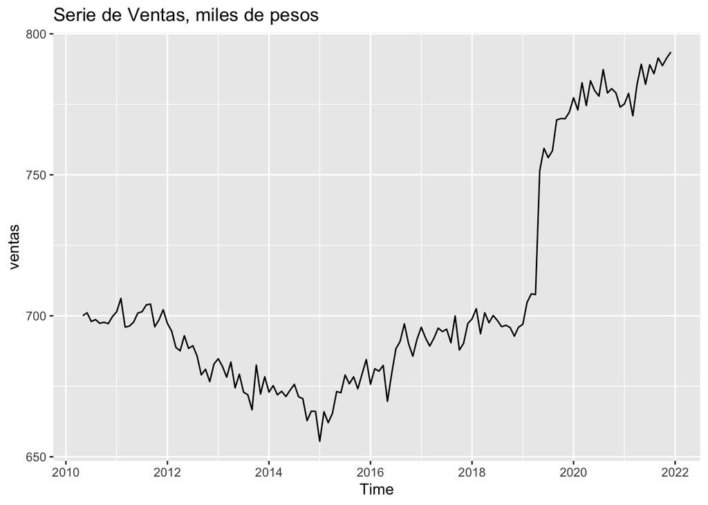

```r
autoplot(ventas)+
  ggtitle("Serie de Ventas, miles de pesos")
```

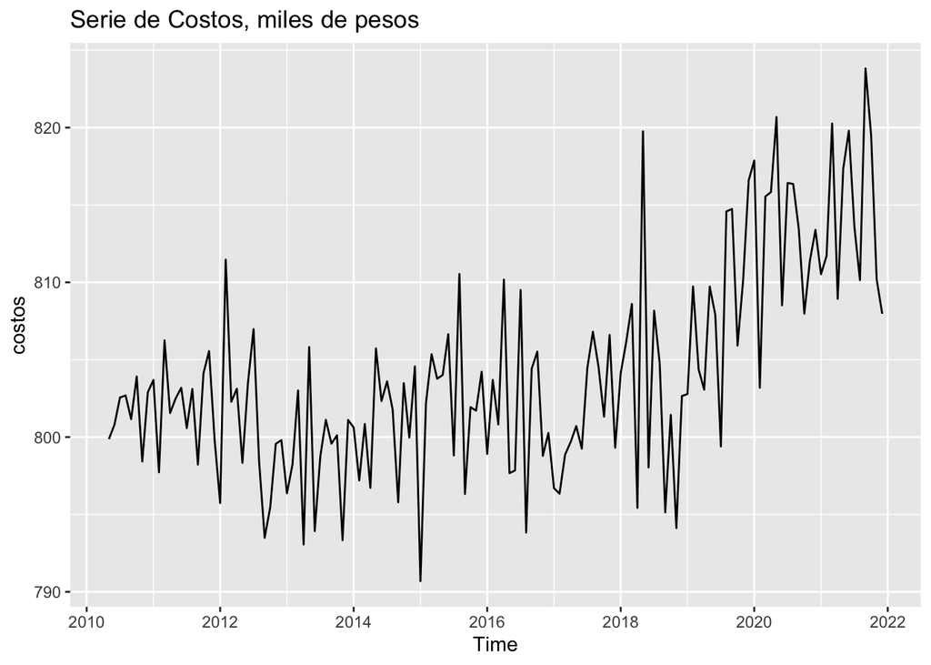

```r
autoplot(costos)+
  ggtitle("Serie de Costos, miles de pesos")
```

Con el comportamiento de la ventas se recomienda utilizar el método de holt, y con el la serie de costos el método de holt amortiguado.

Realizamos el pronostico

```r
ventas_p <- holt(ventas, h=40)

costos_p <- holt(costos, h=40, damped = TRUE)

ventas_p
```

```
##          Point Forecast    Lo 80    Hi 80    Lo 95    Hi 95
## Jan 2022       794.8759 786.6797 803.0722 782.3408 807.4110
## Feb 2022       796.3880 785.9800 806.7959 780.4703 812.3056
## Mar 2022       797.9000 785.5583 810.2417 779.0250 816.7750
## Apr 2022       799.4121 785.2965 813.5276 777.8242 820.9999
## May 2022       800.9241 785.1376 816.7106 776.7808 825.0674
## Jun 2022       802.4362 785.0492 819.8231 775.8451 829.0272
## Jul 2022       803.9482 785.0108 822.8856 774.9859 832.9105
## Aug 2022       805.4603 785.0088 825.9117 774.1824 836.7381
## Sep 2022       806.9723 785.0334 828.9112 773.4197 840.5249
## Oct 2022       808.4844 785.0776 831.8911 772.6868 844.2819
## Nov 2022       809.9964 785.1360 834.8568 771.9757 848.0171
## Dec 2022       811.5085 785.2044 837.8125 771.2798 851.7371
## Jan 2023       813.0205 785.2795 840.7615 770.5943 855.4467
## Feb 2023       814.5326 785.3587 843.7064 769.9150 859.1501
## Mar 2023       816.0446 785.4399 846.6493 769.2388 862.8504
## Apr 2023       817.5567 785.5214 849.5919 768.5629 866.5504
## May 2023       819.0687 785.6016 852.5358 767.8852 870.2522
## Jun 2023       820.5808 785.6794 855.4821 767.2038 873.9577
## Jul 2023       822.0928 785.7538 858.4318 766.5171 877.6685
## Aug 2023       823.6048 785.8239 861.3858 765.8238 881.3859
## Sep 2023       825.1169 785.8889 864.3449 765.1228 885.1110
## Oct 2023       826.6289 785.9482 867.3097 764.4131 888.8448
## Nov 2023       828.1410 786.0013 870.2807 763.6939 892.5881
## Dec 2023       829.6530 786.0477 873.2584 762.9645 896.3416
## Jan 2024       831.1651 786.0871 876.2431 762.2242 900.1060
## Feb 2024       832.6771 786.1190 879.2353 761.4726 903.8817
## Mar 2024       834.1892 786.1432 882.2352 760.7092 907.6692
## Apr 2024       835.7012 786.1594 885.2431 759.9335 911.4690
## May 2024       837.2133 786.1673 888.2593 759.1452 915.2814
## Jun 2024       838.7253 786.1668 891.2839 758.3441 919.1066
## Jul 2024       840.2374 786.1578 894.3170 757.5298 922.9450
## Aug 2024       841.7494 786.1400 897.3589 756.7021 926.7968
## Sep 2024       843.2615 786.1133 900.4097 755.8609 930.6621
## Oct 2024       844.7735 786.0776 903.4695 755.0059 934.5412
## Nov 2024       846.2856 786.0329 906.5383 754.1370 938.4342
## Dec 2024       847.7976 785.9790 909.6163 753.2541 942.3412
## Jan 2025       849.3097 785.9158 912.7036 752.3571 946.2623
## Feb 2025       850.8217 785.8434 915.8001 751.4459 950.1976
## Mar 2025       852.3338 785.7616 918.9060 750.5204 954.1472
## Apr 2025       853.8458 785.6704 922.0213 749.5805 958.1111
```

```r
costos_p
```

```
##          Point Forecast    Lo 80    Hi 80    Lo 95    Hi 95
## Jan 2022       814.6895 808.2659 821.1130 804.8655 824.5135
## Feb 2022       814.6057 808.1379 821.0735 804.7141 824.4973
## Mar 2022       814.5387 808.0115 821.0659 804.5562 824.5212
## Apr 2022       814.4851 807.8850 821.0851 804.3912 824.5790
## May 2022       814.4422 807.7580 821.1263 804.2196 824.6647
## Jun 2022       814.4078 807.6304 821.1852 804.0427 824.7730
## Jul 2022       814.3804 807.5026 821.2582 803.8617 824.8991
## Aug 2022       814.3584 807.3747 821.3422 803.6777 825.0391
## Sep 2022       814.3409 807.2472 821.4345 803.4920 825.1897
## Oct 2022       814.3268 807.1203 821.5333 803.3054 825.3482
## Nov 2022       814.3156 806.9944 821.6367 803.1188 825.5123
## Dec 2022       814.3066 806.8696 821.7436 802.9327 825.6805
## Jan 2023       814.2994 806.7460 821.8527 802.7475 825.8512
## Feb 2023       814.2936 806.6238 821.9634 802.5637 826.0235
## Mar 2023       814.2890 806.5031 822.0749 802.3814 826.1966
## Apr 2023       814.2853 806.3838 822.1868 802.2010 826.3697
## May 2023       814.2824 806.2660 822.2987 802.0224 826.5424
## Jun 2023       814.2800 806.1497 822.4103 801.8457 826.7143
## Jul 2023       814.2781 806.0348 822.5214 801.6711 826.8851
## Aug 2023       814.2766 805.9215 822.6318 801.4985 827.0547
## Sep 2023       814.2754 805.8095 822.7413 801.3279 827.2229
## Oct 2023       814.2744 805.6989 822.8500 801.1593 827.3896
## Nov 2023       814.2737 805.5897 822.9576 800.9927 827.5547
## Dec 2023       814.2730 805.4818 823.0643 800.8280 827.7181
## Jan 2024       814.2726 805.3752 823.1700 800.6651 827.8800
## Feb 2024       814.2722 805.2698 823.2746 800.5042 828.0401
## Mar 2024       814.2718 805.1656 823.3781 800.3450 828.1987
## Apr 2024       814.2716 805.0625 823.4806 800.1876 828.3556
## May 2024       814.2714 804.9606 823.5821 800.0318 828.5109
## Jun 2024       814.2712 804.8598 823.6826 799.8777 828.6647
## Jul 2024       814.2711 804.7601 823.7821 799.7253 828.8169
## Aug 2024       814.2710 804.6614 823.8806 799.5744 828.9676
## Sep 2024       814.2709 804.5637 823.9781 799.4250 829.1168
## Oct 2024       814.2708 804.4669 824.0747 799.2771 829.2646
## Nov 2024       814.2708 804.3712 824.1704 799.1306 829.4110
## Dec 2024       814.2707 804.2763 824.2652 798.9855 829.5560
## Jan 2025       814.2707 804.1823 824.3591 798.8418 829.6996
## Feb 2025       814.2707 804.0892 824.4522 798.6994 829.8420
## Mar 2025       814.2707 803.9969 824.5444 798.5583 829.9830
## Apr 2025       814.2706 803.9054 824.6358 798.4184 830.1228
```

2. Utilizando los pronósticos anteriores, genera una serie de utilidades (Ventas pronosticadas – Costos pronosticados) ¿en qué fecha se espera que se llegue a un punto de equilibrio esta empresa? Hint: Para generar este cálculo, es necesario tomar la estimación puntual de las ventas y restar la estimación puntual de los costos. Por ejemplo: Si el pronóstico de las ventas esta en el objeto “ventas_p” y el pronóstico de los costos en el objeto “costos_p”, para realizar este cálculo utilizo la siguientes sintaxis: ventas_pmean - costos_pmean

```r
utilidades <- ventas_p$mean - costos_p$mean

utilidades
```

```
##              Jan         Feb         Mar         Apr         May         Jun
## 2022 -19.8135771 -18.2177466 -16.6386722 -15.0730028 -13.5180572 -11.9716908
## 2023  -1.2788623   0.2389449   1.7556007   3.2713352   4.7863329   6.3007410
## 2024  16.8925446  18.4049902  19.9173565  21.4296596  22.9419120  24.4541240
## 2025  35.0389853  36.5510623  38.0631339  39.5752012
##              Jul         Aug         Sep         Oct         Nov         Dec
## 2022 -10.4321877  -8.8981752  -7.3685553  -5.8424494  -4.3191546  -2.7981089
## 2023   7.8146774   9.3282365  10.8414938  12.3545096  13.8673322  15.3800002
## 2024  25.9663035  27.4784570  28.9905899  30.5027061  32.0148091  33.5269014
## 2025
```

De acuerdo con estos este pronostico se espera llegar a un punto de equilibrio en febrero de 2023.

3. Genera una serie de Utilidades con las series originales y utiliza esta serie para realizar un pronóstico de los siguientes 40 meses, compara este pronóstico al generado en el punto 2 ¿Qué diferencias se observan?

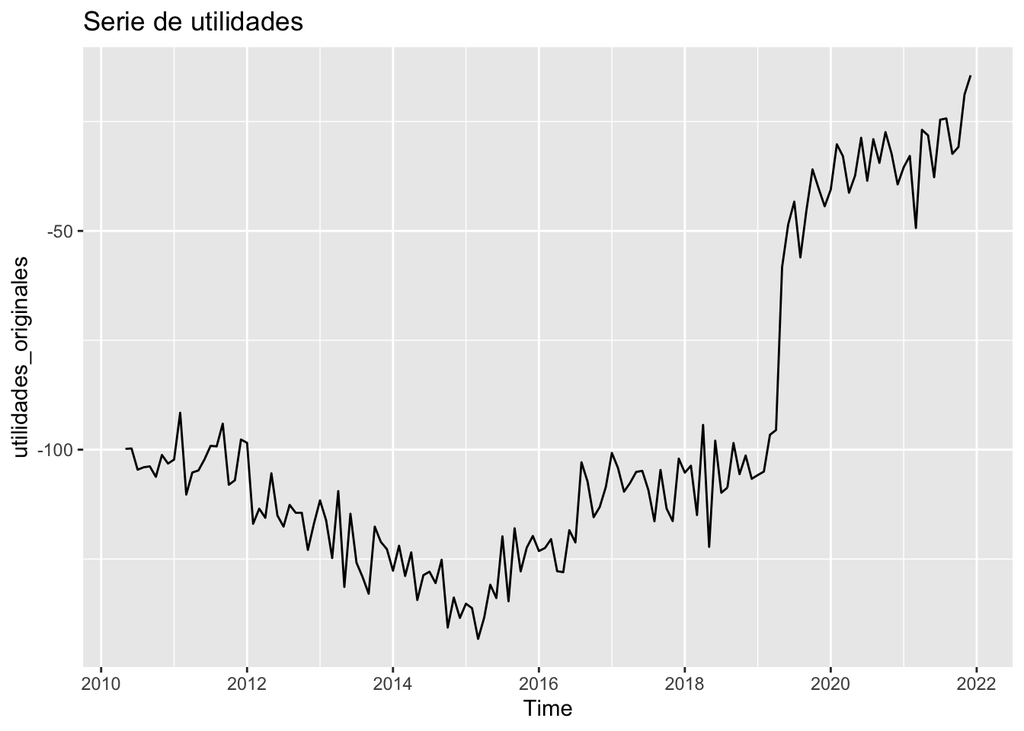

```r
utilidades_originales <- ventas-costos

autoplot(utilidades_originales)+
  ggtitle("Serie de utilidades")
```

```r
utilidades_p <- holt(utilidades_originales, h=40)

utilidades_p
```

```
##          Point Forecast     Lo 80       Hi 80     Lo 95        Hi 95
## Jan 2022    -16.4053367 -27.12444  -5.6862356 -32.79879  -0.01188624
## Feb 2022    -14.9397987 -27.17371  -2.7058890 -33.64995   3.77035158
## Mar 2022    -13.4742607 -27.14178   0.1932577 -34.37693   7.42840496
## Apr 2022    -12.0087227 -27.05446   3.0370194 -35.01920  11.00175418
## May 2022    -10.5431847 -26.92812   5.8417510 -35.60178  14.51541205
## Jun 2022     -9.0776467 -26.77381   8.6185120 -36.14159  17.98629258
## Jul 2022     -7.6121087 -26.59936  11.3751446 -36.65061  21.42638928
## Aug 2022     -6.1465707 -26.41056  14.1174137 -37.13766  24.84451901
## Sep 2022     -4.6810327 -26.21174  16.8496790 -37.60941  28.24734931
## Oct 2022     -3.2154947 -26.00630  19.5753132 -38.07103  31.64003816
## Nov 2022     -1.7499567 -25.79689  22.2969742 -38.52656  35.02665042
## Dec 2022     -0.2844187 -25.58563  25.0167889 -38.97928  38.41043918
## Jan 2023      1.1811193 -25.37424  27.7364819 -39.43180  41.79404164
## Feb 2023      2.6466573 -25.16415  30.4574662 -39.88630  45.17961908
## Mar 2023      4.1121953 -24.95652  33.1809108 -40.34457  48.56895925
## Apr 2023      5.5777333 -24.75232  35.9077903 -40.80809  51.96355262
## May 2023      7.0432713 -24.55238  38.6389227 -41.27811  55.36465021
## Jun 2023      8.5088093 -24.35738  41.3749985 -41.75569  58.77330813
## Jul 2023      9.9743473 -24.16791  44.1166036 -42.24173  62.19042227
## Aug 2023     11.4398853 -23.98447  46.8642368 -42.73699  65.61675576
## Sep 2023     12.9054233 -23.80748  49.6183247 -43.24211  69.05296081
## Oct 2023     14.3709613 -23.63731  52.3792328 -43.75767  72.49959636
## Nov 2023     15.8364993 -23.47428  55.1472749 -44.28414  75.95714247
## Dec 2023     17.3020373 -23.31865  57.9227210 -44.82194  79.42601202
## Jan 2024     18.7675753 -23.17065  60.7058035 -45.37141  82.90656046
## Feb 2024     20.2331133 -23.03050  63.4967226 -45.93287  86.39909387
## Mar 2024     21.6986513 -22.89835  66.2956505 -46.50657  89.90387575
## Apr 2024     23.1641893 -22.77436  69.1027353 -47.09275  93.42113267
## May 2024     24.6297273 -22.65865  71.9181044 -47.69160  96.95105914
## Jun 2024     26.0952653 -22.55134  74.7418665 -48.30329 100.49382164
## Jul 2024     27.5608033 -22.45251  77.5741145 -48.92796 104.04956218
## Aug 2024     29.0263413 -22.36224  80.4149272 -49.56572 107.61840129
## Sep 2024     30.4918793 -22.28061  83.2643710 -50.21668 111.20044057
## Oct 2024     31.9574173 -22.20767  86.1225014 -50.88093 114.79576497
## Nov 2024     33.4229553 -22.14345  88.9893645 -51.55853 118.40444474
## Dec 2024     34.8884933 -22.08801  91.8649976 -52.24955 122.02653706
## Jan 2025     36.3540313 -22.04137  94.7494305 -52.95403 125.66208759
## Feb 2025     37.8195693 -22.00355  97.6426865 -53.67199 129.31113173
## Mar 2025     39.2851073 -21.97457 100.5447826 -54.40348 132.97369576
## Apr 2025     40.7506453 -21.95444 103.4557307 -55.14851 136.64979782
```

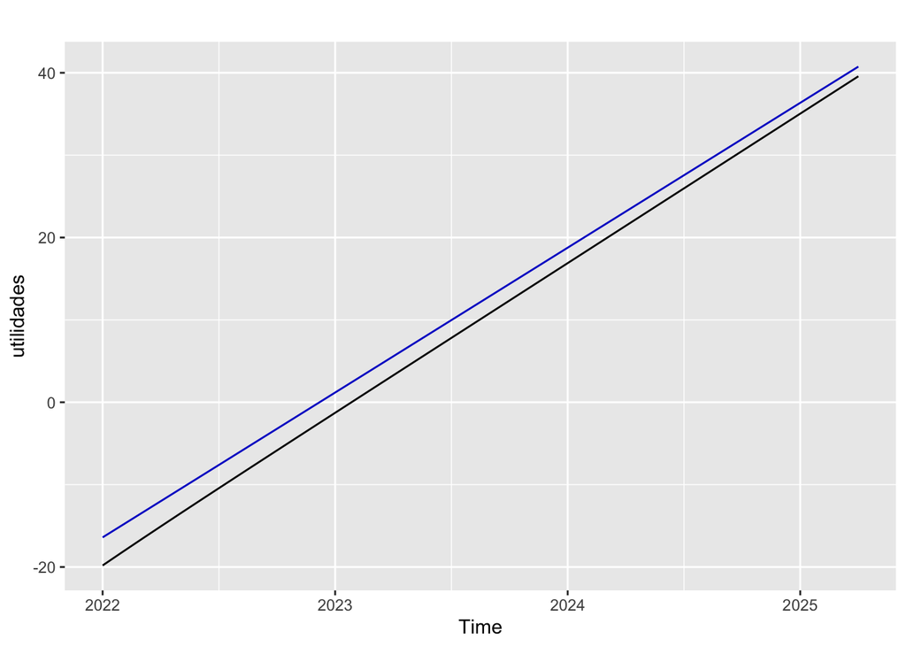

```r
autoplot(utilidades)+
  autolayer(utilidades_p, PI=FALSE)
```

4. Analiza tu pronostico del punto 3, en un escenario pesimista, ¿en qué fecha se llega a un punto de equilibro? ¿y en un escenario optimista? Justifica tu respuesta.

```r
utilidades_p
```

```
##          Point Forecast     Lo 80       Hi 80     Lo 95        Hi 95
## Jan 2022    -16.4053367 -27.12444  -5.6862356 -32.79879  -0.01188624
## Feb 2022    -14.9397987 -27.17371  -2.7058890 -33.64995   3.77035158
## Mar 2022    -13.4742607 -27.14178   0.1932577 -34.37693   7.42840496
## Apr 2022    -12.0087227 -27.05446   3.0370194 -35.01920  11.00175418
## May 2022    -10.5431847 -26.92812   5.8417510 -35.60178  14.51541205
## Jun 2022     -9.0776467 -26.77381   8.6185120 -36.14159  17.98629258
## Jul 2022     -7.6121087 -26.59936  11.3751446 -36.65061  21.42638928
## Aug 2022     -6.1465707 -26.41056  14.1174137 -37.13766  24.84451901
## Sep 2022     -4.6810327 -26.21174  16.8496790 -37.60941  28.24734931
## Oct 2022     -3.2154947 -26.00630  19.5753132 -38.07103  31.64003816
## Nov 2022     -1.7499567 -25.79689  22.2969742 -38.52656  35.02665042
## Dec 2022     -0.2844187 -25.58563  25.0167889 -38.97928  38.41043918
## Jan 2023      1.1811193 -25.37424  27.7364819 -39.43180  41.79404164
## Feb 2023      2.6466573 -25.16415  30.4574662 -39.88630  45.17961908
## Mar 2023      4.1121953 -24.95652  33.1809108 -40.34457  48.56895925
## Apr 2023      5.5777333 -24.75232  35.9077903 -40.80809  51.96355262
## May 2023      7.0432713 -24.55238  38.6389227 -41.27811  55.36465021
## Jun 2023      8.5088093 -24.35738  41.3749985 -41.75569  58.77330813
## Jul 2023      9.9743473 -24.16791  44.1166036 -42.24173  62.19042227
## Aug 2023     11.4398853 -23.98447  46.8642368 -42.73699  65.61675576
## Sep 2023     12.9054233 -23.80748  49.6183247 -43.24211  69.05296081
## Oct 2023     14.3709613 -23.63731  52.3792328 -43.75767  72.49959636
## Nov 2023     15.8364993 -23.47428  55.1472749 -44.28414  75.95714247
## Dec 2023     17.3020373 -23.31865  57.9227210 -44.82194  79.42601202
## Jan 2024     18.7675753 -23.17065  60.7058035 -45.37141  82.90656046
## Feb 2024     20.2331133 -23.03050  63.4967226 -45.93287  86.39909387
## Mar 2024     21.6986513 -22.89835  66.2956505 -46.50657  89.90387575
## Apr 2024     23.1641893 -22.77436  69.1027353 -47.09275  93.42113267
## May 2024     24.6297273 -22.65865  71.9181044 -47.69160  96.95105914
## Jun 2024     26.0952653 -22.55134  74.7418665 -48.30329 100.49382164
## Jul 2024     27.5608033 -22.45251  77.5741145 -48.92796 104.04956218
## Aug 2024     29.0263413 -22.36224  80.4149272 -49.56572 107.61840129
## Sep 2024     30.4918793 -22.28061  83.2643710 -50.21668 111.20044057
## Oct 2024     31.9574173 -22.20767  86.1225014 -50.88093 114.79576497
## Nov 2024     33.4229553 -22.14345  88.9893645 -51.55853 118.40444474
## Dec 2024     34.8884933 -22.08801  91.8649976 -52.24955 122.02653706
## Jan 2025     36.3540313 -22.04137  94.7494305 -52.95403 125.66208759
## Feb 2025     37.8195693 -22.00355  97.6426865 -53.67199 129.31113173
## Mar 2025     39.2851073 -21.97457 100.5447826 -54.40348 132.97369576
## Apr 2025     40.7506453 -21.95444 103.4557307 -55.14851 136.64979782
```

Utilizando el *nivel de confianza del 80%* en un escenario pesimista no se llega un punto de equilibrio. Y en un escenario optimista, se llega al equilibrio en marzo de 2022.

1. Si cambiamos el nivel a confianza al 60%, en qué fecha se llega a un punto de equilibrio tanto en un escenario pesimista como optimista

```r
utilidades_p2 <- holt(utilidades_originales, h=40, level=.60)
utilidades_p2
```

```
##          Point Forecast       Lo 60      Hi 60
## Jan 2022    -16.4053367 -23.4447906 -9.3658829
## Feb 2022    -14.9397987 -22.9740585 -6.9055390
## Mar 2022    -13.4742607 -22.4500008 -4.4985206
## Apr 2022    -12.0087227 -21.8895706 -2.1278748
## May 2022    -10.5431847 -21.3035085  0.2171391
## Jun 2022     -9.0776467 -20.6990776  2.5437842
## Jul 2022     -7.6121087 -20.0814279  4.8572105
## Aug 2022     -6.1465707 -19.4543454  7.1612040
## Sep 2022     -4.6810327 -18.8206933  9.4586279
## Oct 2022     -3.2154947 -18.1826864 11.7516969
## Nov 2022     -1.7499567 -17.5420701 14.0421567
## Dec 2022     -0.2844187 -16.9002414 16.3314040
## Jan 2023      1.1811193 -16.2583327 18.6205713
## Feb 2023      2.6466573 -15.6172721 20.9105867
## Mar 2023      4.1121953 -14.9778272 23.2022178
## Apr 2023      5.5777333 -14.3406381 25.4961046
## May 2023      7.0432713 -13.7062419 27.7927845
## Jun 2023      8.5088093 -13.0750922 30.0927108
## Jul 2023      9.9743473 -12.4475736 32.3962682
## Aug 2023     11.4398853 -11.8240139 34.7037845
## Sep 2023     12.9054233 -11.2046931 37.0155397
## Oct 2023     14.3709613 -10.5898512 39.3317738
## Nov 2023     15.8364993  -9.9796944 41.6526930
## Dec 2023     17.3020373  -9.3744000 43.9784745
## Jan 2024     18.7675753  -8.7741205 46.3092711
## Feb 2024     20.2331133  -8.1789875 48.6452140
## Mar 2024     21.6986513  -7.5891140 50.9864166
## Apr 2024     23.1641893  -7.0045974 53.3329760
## May 2024     24.6297273  -6.4255212 55.6849758
## Jun 2024     26.0952653  -5.8519568 58.0424874
## Jul 2024     27.5608033  -5.2839654 60.4055719
## Aug 2024     29.0263413  -4.7215985 62.7742810
## Sep 2024     30.4918793  -4.1648998 65.1486584
## Oct 2024     31.9574173  -3.6139059 67.5287405
## Nov 2024     33.4229553  -3.0686469 69.9145574
## Dec 2024     34.8884933  -2.5291473 72.3061338
## Jan 2025     36.3540313  -1.9954267 74.7034893
## Feb 2025     37.8195693  -1.4675004 77.1066390
## Mar 2025     39.2851073  -0.9453796 79.5155942
## Apr 2025     40.7506453  -0.4290721 81.9303627
```

Con una confianza del 60% en un escenario pesimista, no se llega a un punto de equilibrio, sin embargo en un escenario optimisa se llega aproximadamente en mayo de 2022.

Buscamos el pronostico que tenga el *menor error* (medido a traves del Root Mean Square Error) Raiz del error cuadratico medio

```r
summary(costos_p)
```

```
##
## Forecast method: Damped Holt's method
##
## Model Information:
## Damped Holt's method
##
## Call:
##  holt(y = costos, h = 40, damped = TRUE)
##
##   Smoothing parameters:
##     alpha = 0.0935
##     beta  = 0.0301
##     phi   = 0.8
##
##   Initial states:
##     l = 802.7633
##     b = 0.032
##
##   sigma:  5.0123
##
##      AIC     AICc      BIC
## 1150.071 1150.702 1167.721
##
## Error measures:
##                     ME     RMSE      MAE        MPE      MAPE      MASE
## Training set 0.3800329 4.922011 3.926852 0.04365454 0.4876499 0.6781931
##                    ACF1
## Training set -0.1685943
##
## Forecasts:
##          Point Forecast    Lo 80    Hi 80    Lo 95    Hi 95
## Jan 2022       814.6895 808.2659 821.1130 804.8655 824.5135
## Feb 2022       814.6057 808.1379 821.0735 804.7141 824.4973
## Mar 2022       814.5387 808.0115 821.0659 804.5562 824.5212
## Apr 2022       814.4851 807.8850 821.0851 804.3912 824.5790
## May 2022       814.4422 807.7580 821.1263 804.2196 824.6647
## Jun 2022       814.4078 807.6304 821.1852 804.0427 824.7730
## Jul 2022       814.3804 807.5026 821.2582 803.8617 824.8991
## Aug 2022       814.3584 807.3747 821.3422 803.6777 825.0391
## Sep 2022       814.3409 807.2472 821.4345 803.4920 825.1897
```

[output cut: 16 more lines]

```
## Feb 2024       814.2722 805.2698 823.2746 800.5042 828.0401
## Mar 2024       814.2718 805.1656 823.3781 800.3450 828.1987
## Apr 2024       814.2716 805.0625 823.4806 800.1876 828.3556
## May 2024       814.2714 804.9606 823.5821 800.0318 828.5109
## Jun 2024       814.2712 804.8598 823.6826 799.8777 828.6647
## Jul 2024       814.2711 804.7601 823.7821 799.7253 828.8169
## Aug 2024       814.2710 804.6614 823.8806 799.5744 828.9676
## Sep 2024       814.2709 804.5637 823.9781 799.4250 829.1168
## Oct 2024       814.2708 804.4669 824.0747 799.2771 829.2646
## Nov 2024       814.2708 804.3712 824.1704 799.1306 829.4110
## Dec 2024       814.2707 804.2763 824.2652 798.9855 829.5560
## Jan 2025       814.2707 804.1823 824.3591 798.8418 829.6996
## Feb 2025       814.2707 804.0892 824.4522 798.6994 829.8420
## Mar 2025       814.2707 803.9969 824.5444 798.5583 829.9830
## Apr 2025       814.2706 803.9054 824.6358 798.4184 830.1228
```